# Weight Lifting Technique: Predictions

Rona Stewart

2024-03-15

## Executive Summary

The objective of this project is to develop a model and use this to predict whether the correct technique is used when lifting weights or not. The model will take data generated from accelerometers on the belt, forearm, arm, and dumbbell (each of which provide 38 outputs) of six participants who were asked to perform barbell lifts correctly and incorrectly in five different ways.

Initial exploratory analysis was conducted, considering boxplots of potential predictors against the outcome (see Appendix 2), and to create an initial exploratory model and assess the variables of greatest importance in this. Based on this initial exploratory analysis, 14 potential predictor variables were identified.

Based on this, predictions for the next 20 records include 7 in classe A, 8 in classe B, 1 in each of classes C and D and 3 in classe E (see Appendix 4).

## Data Partition

Prior to conducting any analysis or model fitting, the training data is further split to enable initial assessments of the model fit on a validation set.

```r
### Set seed to ensure reproducability of results
set.seed(1240)
### Create a vector identifying those elements for the training set
inTrain <- createDataPartition(y = training$classe, p=0.7, list = FALSE)
train <- training[inTrain,]
validation <- training[-inTrain,]
```

## Dimension Reduction

As there are a large number of potential predictor variables (159), the first exercise is to reduce this number to a more practical number for consideration in fitting a model. This is done by:

- Removing the variables which are identifiers (original columns 1:7),
- Removing the variables with a near zero variance as these are unlikely to be useful predictors, and
- Removing the variables which consist mainly of NA values

## Exploratory Analysis

The training data set has 13737 observations of 53 variables (including the outcome variable, “classe”. As such these variables are retained in the dataset of interest and used for exploratory analysis. Initially, boxplots were created to consider where there were apparent differences in the outcome (classe) based on the range of predictor variables. These are included at Appendix 2. From these plots, the following were identified as potentially powerful predictor variables:

- roll_belt, total_accel_belt, yaw_belt;
- accel_arm_x, magnet_arm_x; and
- pitch_forearm

As a second method of identifying powerful predictors, an initial exploratory model is fit using the standard random tree method and all 52 potential predictor variables (note that random tree was selected as a starting point for expediency, as a method including bagging would likely have a very high run time). The variable importance from this exploratory model is shown in the below graph.

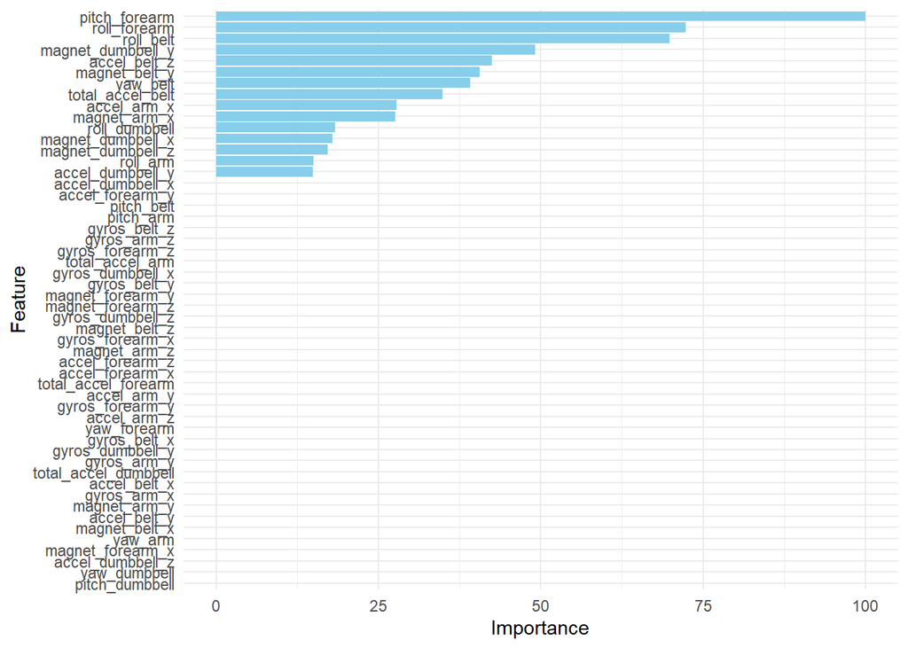

## Model Development

```
##   Ref                       Method Accuracy
## 1   1 Linear Discriminate Analysis    0.542
## 2   2                  Random Tree    0.513
## 3   3                Random Forest    0.984
## 4   4          Boosting with Trees    0.914
```

Given that there are still a large number (14) of predictors, there is a risk of overfitting. As a result, the models are re-run, using only the top five predictors for each model to assess the reduction in accuracy:

```
##   Ref                       Method Accuracy Reduced_predictor_accuracy
## 1   1 Linear Discriminate Analysis    0.542                      0.411
## 2   2                  Random Tree    0.513                      0.351
## 3   3                Random Forest    0.984                      0.950
## 4   4          Boosting with Trees    0.914                      0.860
```

Given the relatively small decrease in accuracy, and the use of the same top five predictors, models 3a and 4a will be used to reduce the risk of bias. Based on this, a stacked model is created using models 3a and 4a from above to assess whether this further enhances the accuracy.

The random forest method is used to combine the models, resulting in an accuracy of 0.986.

## Model Evaluation

Finally, using the models 3a, 4a and the combined model generated above, predictions are made and evaluated on the validation set to assess the out-of-sample accuracy.

These can be summarised as:

- Model 3a (using random forest, 5 variables) accuracy is 0.949
- Model 4a (using boosting with trees, 5 variables) accuracy is 0.868
- Staked model (combining models 3a and 4a) accuracy is 0.949

## Conclusion

As the out-of-sample accuracy rate is highest using the random forest algorithm (ref 3a), this is used to create predictions on the test sample. Note that the accuracy of these predictions cannot be provided in this report, as the observed outcomes are not yet known, however the predictions are included at appendix 4.

## Appendix 1: Environment

The environment this analyses was undertaken in is described below:  
* Date at which data obtained from url’s: 2024-03-15 * OS: Windows  
* CPU: intel COREi5  
* Software: RStudio 2023.12.1+402 “Ocean Storm” Release (4da58325ffcff29d157d9264087d4b1ab27f7204, 2024-01-28) for windows, Mozilla/5.0 (Windows NT 10.0; Win64; x64) AppleWebKit/537.36 (KHTML, like Gecko) RStudio/2023.12.1+402 Chrome/116.0.5845.190 Electron/26.2.4 Safari/537.36  
* R version 4.3.2 (2023-10-31 ucrt), Platform: x86_64-w64-mingw32/x64 (64-bit)  
* RStudio libraries: dplyr, caret, ggplot2, gbm, randomForest

## Appendix 2: Exploratory Boxplots

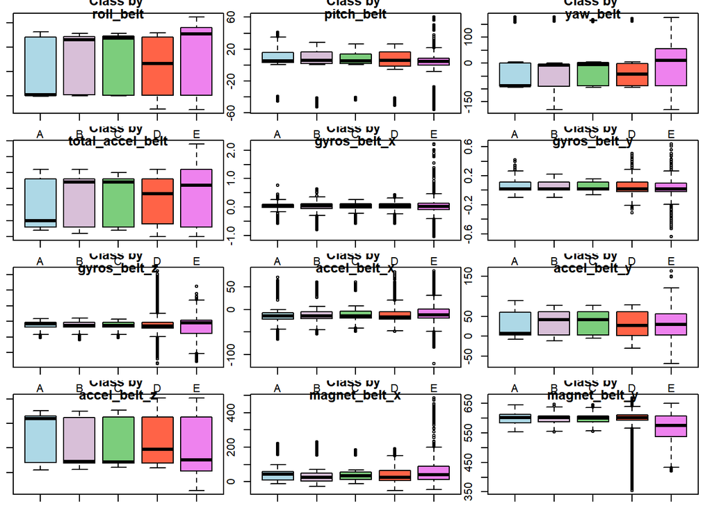

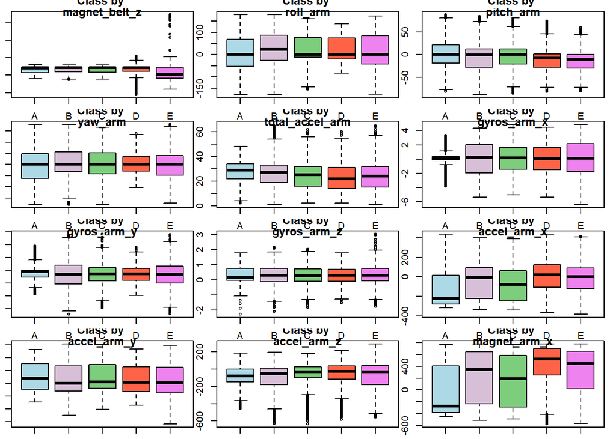

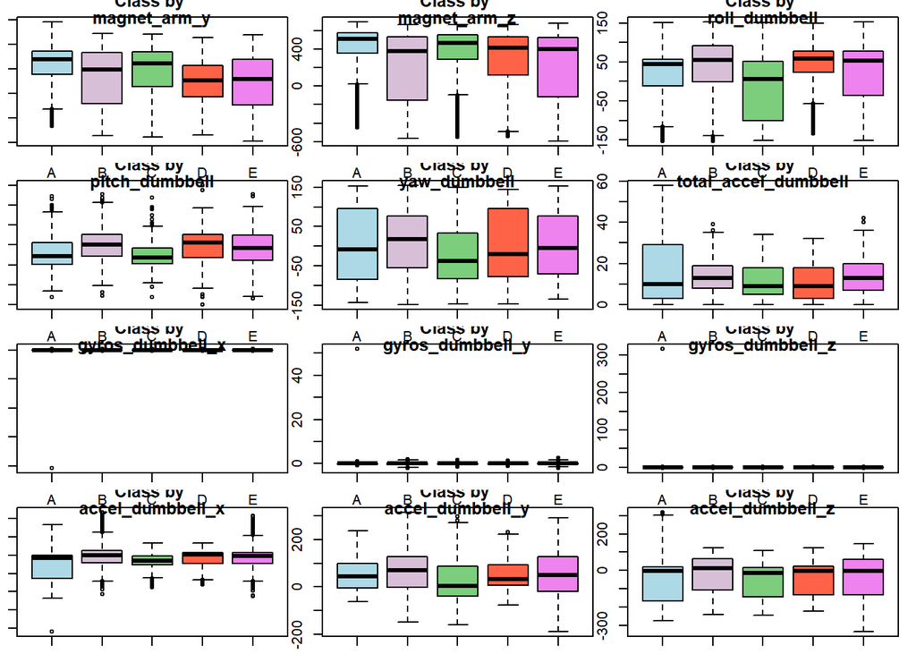

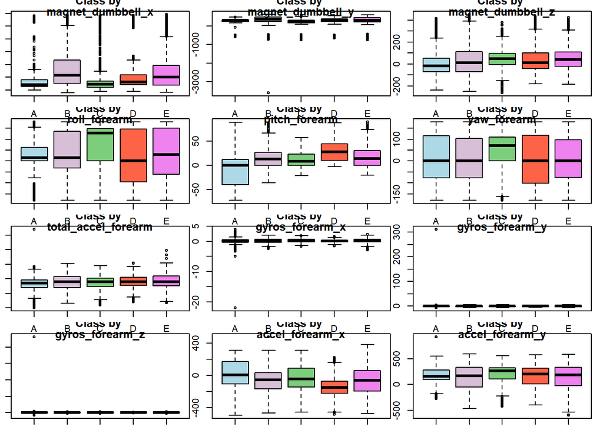

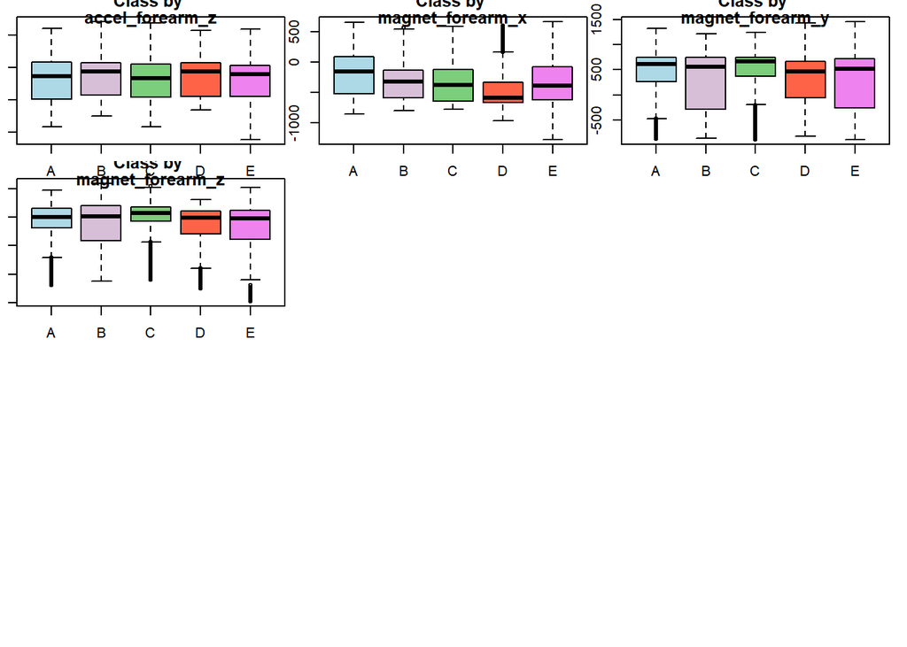

```r
par(mfrow = c(4,3), mar = c(1,1,1,1))
for(i in 1:(ncol(train)-1))plot(train$classe, train[,i], main = c("Class by ",names(train[i])), col = c("lightblue","thistle", "palegreen3", "tomato", "violet" ))
```

## Appendix 3: Confusion Matrices

```r
### Model 1 (LDA, 14 variables)
cm1
```

```
## Bootstrapped (25 reps) Confusion Matrix
##
## (entries are percentual average cell counts across resamples)
##
##           Reference
## Prediction    A    B    C    D    E
##          A 19.5  4.7  4.1  0.9  2.3
##          B  2.5  8.1  2.1  2.5  3.1
##          C  2.7  3.5 10.1  2.3  2.6
##          D  3.2  2.4  1.0  9.2  3.1
##          E  0.5  0.7  0.1  1.3  7.3
##
##  Accuracy (average) : 0.5422
```

```r
### Model 1a (LDA, 5 variables)
cm1a
```

```
## Bootstrapped (25 reps) Confusion Matrix
##
## (entries are percentual average cell counts across resamples)
##
##           Reference
## Prediction    A    B    C    D    E
##          A 20.5  8.8  9.1  4.1  3.5
##          B  2.4  4.2  2.3  4.5  2.1
##          C  0.8  1.2  2.9  1.4  1.8
##          D  4.2  3.9  2.4  4.9  2.4
##          E  0.6  1.3  0.6  1.5  8.5
##
##  Accuracy (average) : 0.4107
```

```r
### Model 2 (rpart, 14 variables)
cm2
```

```
## Bootstrapped (25 reps) Confusion Matrix
##
## (entries are percentual average cell counts across resamples)
##
##           Reference
## Prediction    A    B    C    D    E
##          A 26.0  8.2  7.9  7.2  2.6
##          B  0.5  6.5  0.6  3.1  2.5
##          C  1.7  3.2  8.2  4.1  3.3
##          D  0.3  1.2  0.6  1.8  1.3
##          E  0.2  0.2  0.0  0.2  8.7
##
##  Accuracy (average) : 0.5126
```

```r
### Model 2a (rpart, 5 variables)
cm2a
```

```
## Bootstrapped (25 reps) Confusion Matrix
##
## (entries are percentual average cell counts across resamples)
##
##           Reference
## Prediction    A    B    C    D    E
##          A 25.6 15.9 14.8 12.7 10.1
##          B  0.0  0.0  0.0  0.0  0.0
##          C  0.0  0.0  0.0  0.0  0.0
##          D  2.3  3.1  2.4  3.5  2.2
##          E  0.5  0.3  0.2  0.3  6.0
##
##  Accuracy (average) : 0.3513
```

```r
### Model 3 (rf, 14 variables)
cm3
```

```
##      A    B    C    D    E class.error
## A 3898    7    1    0    0 0.002048131
## B   23 2571   54    9    1 0.032731377
## C    0   33 2357    6    0 0.016277129
## D    1    4   42 2204    1 0.021314387
## E    0    7   12   13 2493 0.012673267
```

```r
### Model 3a (rf, 5 variables)
cm3a
```

```
##      A    B    C    D    E class.error
## A 3818   17   58   12    1  0.02252944
## B   58 2394  109   73   24  0.09932280
## C   31   52 2271   38    4  0.05217028
## D   24   27   61 2134    6  0.05239787
## E    7   46   17   17 2438  0.03445545
```

```r
### Model 4 (gbm, 14 variables)
cm4
```

```
## Bootstrapped (25 reps) Confusion Matrix
##
## (entries are percentual average cell counts across resamples)
##
##           Reference
## Prediction    A    B    C    D    E
##          A 27.6  1.0  0.1  0.1  0.1
##          B  0.4 16.2  1.0  0.3  0.4
##          C  0.3  1.5 15.7  0.9  0.5
##          D  0.2  0.6  0.5 14.9  0.4
##          E  0.1  0.1  0.1  0.1 17.0
##
##  Accuracy (average) : 0.9142
```

```r
### Model 4a (gbm, 5 variables)
cm4a
```

```
## Bootstrapped (25 reps) Confusion Matrix
##
## (entries are percentual average cell counts across resamples)
##
##           Reference
## Prediction    A    B    C    D    E
##          A 26.7  1.2  0.3  0.4  0.2
##          B  0.6 14.0  0.9  0.7  1.0
##          C  0.6  1.9 15.2  1.3  0.7
##          D  0.4  1.7  0.8 14.1  0.4
##          E  0.1  0.5  0.2  0.2 16.1
##
##  Accuracy (average) : 0.8603
```

```r
### Stacked Model
cmcm
```

```
##      A    B    C    D    E class.error
## A 3870    0   29    7    0 0.009216590
## B   13 2575   55   15    0 0.031226486
## C    7   14 2368    7    0 0.011686144
## D   13    3   18 2218    0 0.015097691
## E    2    1    3    4 2515 0.003960396
```

## Appendix 4: Test Predictions

```r
### Then the model can be run on the data in test to create predictions
testpred <- predict(mod3a, newdata = testing[,c(predictors,"problem_id")])
summary(testpred)
```

```
## A B C D E
## 7 8 1 1 3
```

## Appendix 5: R Code

```r
knitr::opts_chunk$set(echo = FALSE, warning = FALSE, message = FALSE, results="hide")
library(dplyr); library(caret); library(ggplot2); library(gbm); library(randomForest)

### Download the relevant data
training <- read.csv("https://d396qusza40orc.cloudfront.net/predmachlearn/pml-training.csv")
testing <- read.csv("https://d396qusza40orc.cloudfront.net/predmachlearn/pml-testing.csv")
```

```r
### Set seed to ensure reproducability of results
set.seed(1240)
### Create a vector identifying those elements for the training set
inTrain <- createDataPartition(y = training$classe, p=0.7, list = FALSE)
train <- training[inTrain,]
validation <- training[-inTrain,]
```

```r
### Amend the class of data fields as necessary
train$classe <- as.factor(train$classe)
validation$classe <- as.factor(validation$classe)

### Subset data to remove identifier variables
train <- train[, -c(1:7)]
validation <- validation[, -c(1:7)]

### Remove predictors with near zero variance
nzv <- nearZeroVar(train,saveMetrics = TRUE)
nearZeroVars <- nzv[nzv$zeroVar==TRUE|nzv$nzv==TRUE,]
train <- train[, !names(train) %in% rownames(nearZeroVars)]

### Remove predictors with high proportion (>90%) NA values
navars <- NULL
for (i in (1:ncol(train))){
        naratio <-  sum(is.na(train[,i]))/nrow(train)
        if (naratio>=0.9){
                navars <- c(navars,names(train)[i])
        }
}
train <- train[, !names(train) %in% navars]

### Replace NAs with 0
train[is.na(train)] <- 0
```

```r
### Produce an initial model using random forest method predicting classe using all remaining variables
explormod <- train(classe~., train, method = "rpart")
```

```r
### Present a graph of the variable importance calculated by the explormod
featImp <- varImp(explormod)
ggplot(featImp, aes(x = rownames(featImp), y = MeanDecreaseAccuracy)) +
        geom_bar(stat = "identity", fill = "skyblue") +
        labs(x = "Feature", y = "Importance") +
        theme_minimal()
```

```r
### First, create objects identifying the outcome and predictor variables
outcome <- train$classe
predvarnames <- rownames(featImp$importance)[1:14]
predvars <- train[,predvarnames]

### Secondly, create a series of models using different methods to assess the accuracy of each
set.seed(58612)
mod1 <- train(classe~., data = train[,c(predvarnames,"classe")], method = "lda") ### using linear discriminate analysis
mod2 <- train(classe~., data = train[,c(predvarnames,"classe")], method = "rpart") ### using random tree
mod3 <- randomForest:: randomForest(predvars, outcome) ### using random forest (note different package for computational speed)
mod4 <- train(classe~., data = train[,c(predvarnames,"classe")], method = "gbm", verbose = FALSE) ### using boosting with trees
```

```r
### Create a table summarising the results of the different models
refs <- 1:4
methods <- c("Linear Discriminate Analysis", "Random Tree", "Random Forest", "Boosting with Trees")
cm1 <- confusionMatrix(mod1)
cm2 <- confusionMatrix(mod2)
cm3 <- mod3$confusion
cm4 <- confusionMatrix(mod4)
accuracy <- c(round(sum(diag(cm1[[1]]))/sum(cm1[[1]]),3), round(sum(diag(cm2[[1]]))/sum(cm2[[1]]),3), round(sum(diag(cm3[,1:5]))/sum(cm3[,1:5]),3), round(sum(diag(cm4[[1]]))/sum(cm4[[1]]),3))
table1 <- data.frame(Ref = refs, Method = methods, Accuracy = accuracy)

print(table1)
```

```r
### Assess the top 5 predictors for each model and re-perform the models based on these alone
mod1pred <- rownames(varImp(mod1)$importance)[1:5]
mod1a <- train(classe~., data = train[,c(mod1pred,"classe")], method = "lda")
mod2pred <- rownames(varImp(mod2)$importance)[1:5]
mod2a <- train(classe~., data = train[,c(mod2pred,"classe")], method = "rpart")
mod3pred <- rownames(importance(mod3))[order(importance(mod3), decreasing = TRUE)[1:5]]
mod3a <- randomForest:: randomForest(train[,mod3pred], outcome)
mod4pred <- rownames(summary.gbm(mod4$finalModel))[1:5]
mod4a <- train(classe~., data = train[,c(mod4pred,"classe")], method = "gbm", verbose = FALSE)

### Create a table summarising the results of the reduced variable models
cm1a <- confusionMatrix(mod1a)
cm2a <- confusionMatrix(mod2a)
cm3a <- mod3a$confusion
cm4a <- confusionMatrix(mod4a)
accuracy2 <- c(round(sum(diag(cm1a[[1]]))/sum(cm1a[[1]]),3), round(sum(diag(cm2a[[1]]))/sum(cm2a[[1]]),3), round(sum(diag(cm3a[,1:5]))/sum(cm3a[,1:5]),3), round(sum(diag(cm4a[[1]]))/sum(cm4a[[1]]),3))

table2 <- data.frame(table1, Reduced_predictor_accuracy = accuracy2)
print(table2)
```

```r
### First create predictions using each of the models
pred3atr <- predict(mod3a, newdata = train)
pred4atr <- predict(mod4a, newdata = train)
predDF <- data.frame(RFpred = pred3atr, GBMpred = pred4atr, classe = train$classe)

### Create a new model based on the predictions
combModFit <- randomForest:: randomForest (classe~., data=predDF)
cmcm <- combModFit$confusion
```

```r
### Create a vector of the predictor variables used
predictors <- rownames(summary.gbm(mod4a$finalModel))

### Reduce the validation dataset to only variables of interest
validation <- validation [,c(predictors, "classe")]

### Create predictions using each of the three models
pred3av <- predict (mod3a, newdata = validation)
pred4av <- predict (mod4a, newdata = validation)
predCMv <- predict (combModFit, newdata = data.frame(RFpred = pred3av, GBMpred = pred4av, validation$classe))

### Create a table of the results (T = correct prediction, F = incorrect)
table3 <- data.frame(RF = (pred3av == validation$classe), GBM = (pred4av == validation$classe), Stacked = (predCMv == validation$classe))

### Assess the out-of-sample accuracy for each
error3a <- sum(table3$RF) / nrow(table3)
error4a <- sum(table3$GBM) / nrow(table3)
errorCM <- sum(table3$Stacked) / nrow(table3)
```